# Pay to Play: The Relationship Between Salary and Athletic Performance

The MLB players association is in contract negotiations with MLB teams for the 2027 baseball season. The current stalemate indicates that there will be a lockout when contacts expire on December 31st, 2026. This could potentially delay or cancel the 2027 season. The issue is primarily to player salary caps. The MLB is the only major american sport without a salary cap, leading to extensive spending. Small market teams want to impose a salary cap in order to remain competitive with large market teams for player acquisition. On the other hand, players argue that the free market system should allow them to make as much money as possible.

In this data story we will examine the impact of salary spending on outcomes at the league, division, and team level from 2005-2019. We use Wins Above Replacement (WAR) and World Series wins to measure ability. Overall, we are asking the question: “Does higher spending mean more success?”

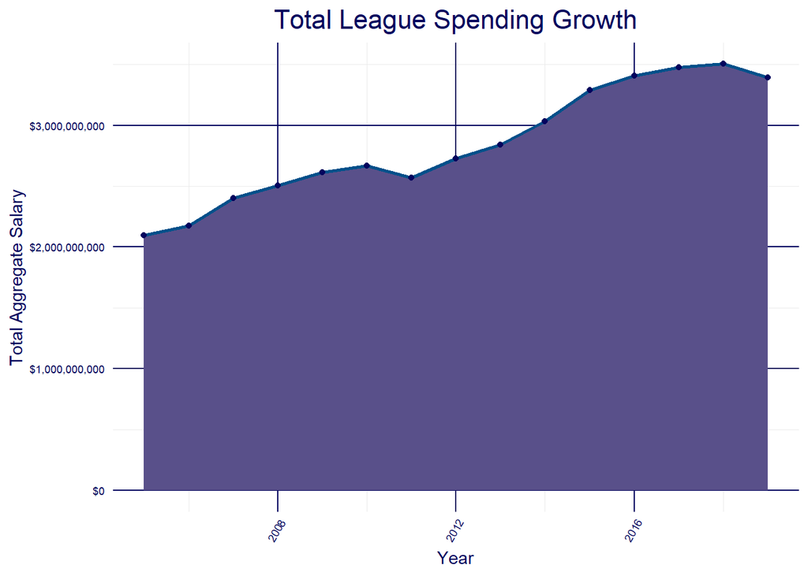

Overall, spending has been increasing in the MLB over the last 2 decades but recent blockbuster contracts have reinvigorated the conversation of a salary cap. In 2024, the Dodgers signed two-way player Shohei Ohtani to a 10 year, 700,000,000 dollar deal. In 2025, Juan Soto signed a 15 year, $765,000,000 contract with the Mets. Meanwhile, the Dodgers have won 3 of the last 5 world series titles.

However, does all the money really mean that teams win more? While spending has increased, the returns of that spending has decreased. The efficiency of each team’s payroll has declined over the same time period.

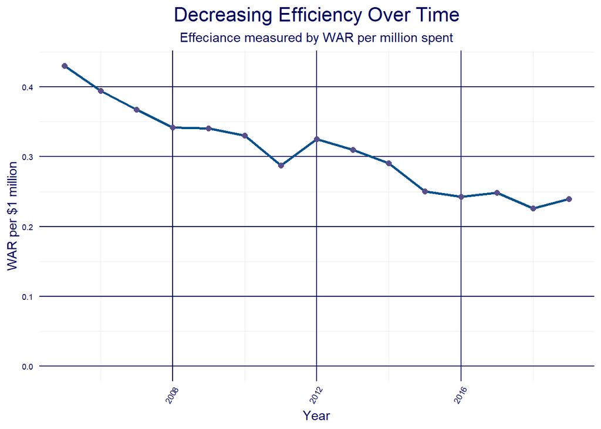

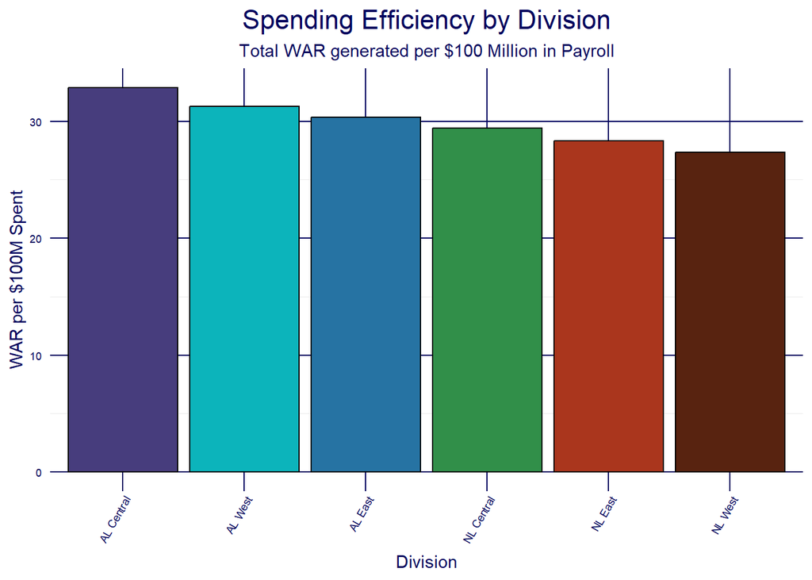

Some divisions are more efficient than others. The AL central, with teams like the Twins, Royals, and Guardians, have been the most efficient. They’ve spent less and preformed better than any other division. On the other hand, the Diamondbacks, Padres, and Giants of the NL West have been the least efficient. The NL West also includes the Dodgers which is a curious case study for the efficiency of a high payroll team.

While the NL is the most inefficient, they have the most number of World series wins. In contrast, the AL Central is tied for last with their NL counterpart. This implies that the value of individuals (measured in WAR) is not always the most pertinent way to measure overall team or division success. World Series wins shows a more holistic view of the whole division’s performance.

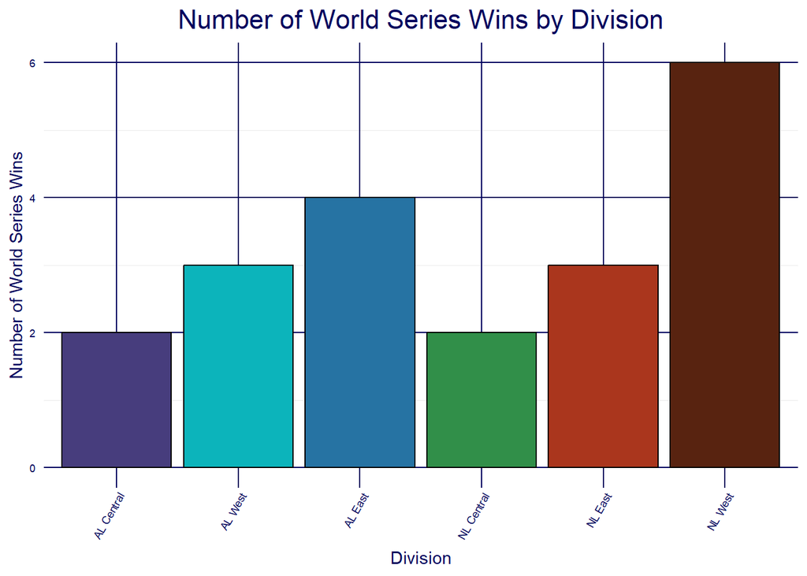

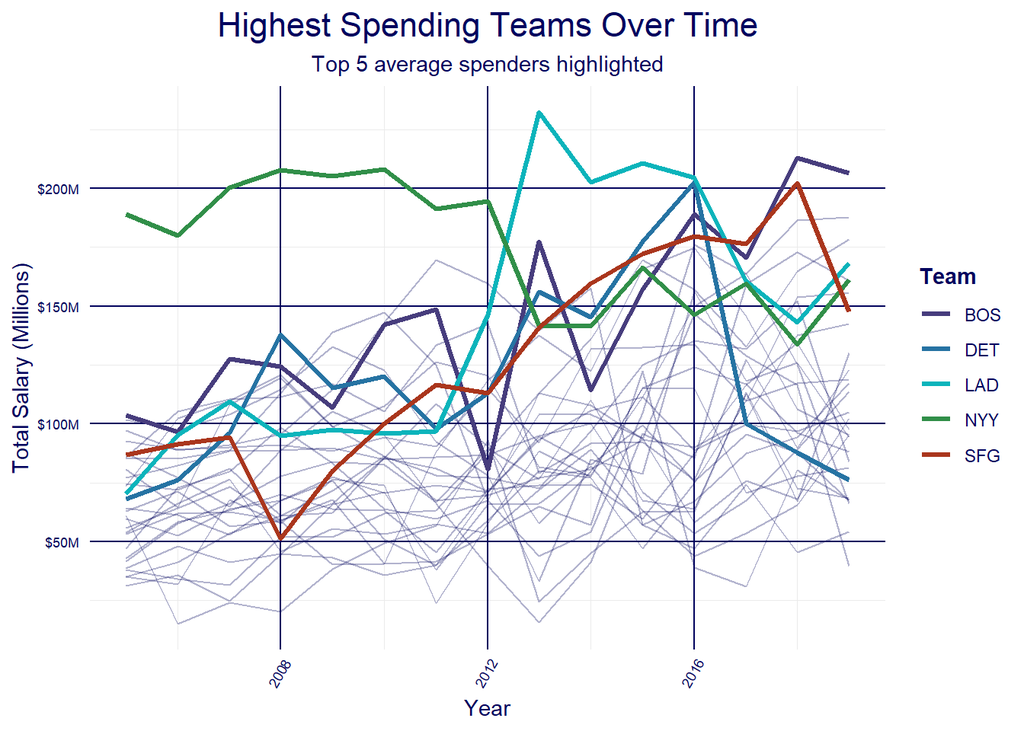

Team spending overtime is inconsistent. Sometimes, teams sign one player for an immense amount or sometimes they sign a handful of valuable players for lower amounts. These trends fluctuate overtime with even the overall highest spenders trading places. “Big market” teams might be overstated in their difference from the rest of the league.

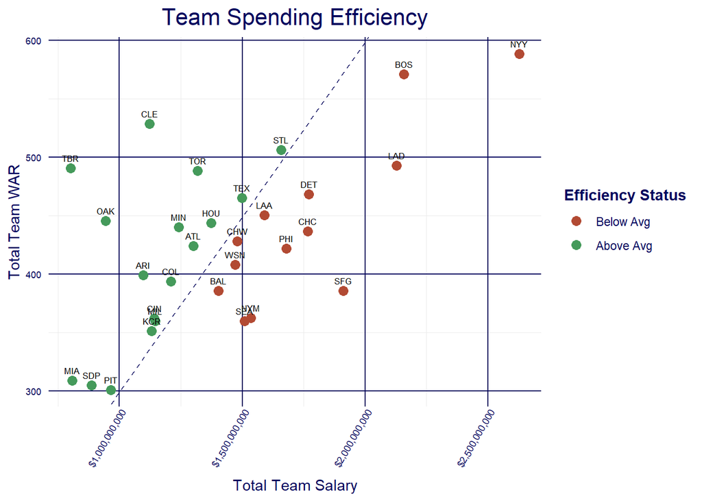

There is not a clear cut solution to the issue of salary caps in the MLB. While spending has been increasing and efficiency decreasing at a league level, looking closer at individual teams shows more variety in trends. Big spending teams aren’t the only culprits to the decline of efficiency. Likewise, spending the most money doesn’t mean you’ll win the world series. In baseball, you have to pay to play, but you don’t necessarily have to pay to win.

### Reflection

I choose my topic because I am interested in labor politics and the baseball lockouts have always been really interesting to me. I wanted to use Data Visualizations to explore the varying arguments about the issue. With sports gambling and team payrolls on the rise, money has consumed the sports industry. I wanted to explore this trend and see if it has an impact on the performance of teams and players.

My intended audience is an audience that may not know anything about this topic. I wanted to give enough background in my project that someone reading a magazine or newspaper could understand my story. I was not intending this to be for experts. I liked the New York Times data story that we looked at in class and I wanted to do something similar with mine. Primarily, I wanted it to be accessible to a larger audience and introduce them to something they may not know about.

The dataset I used was found on github. It was a webscrape of baseball reference which is a very reputable source for baseball statistics and data. While I did not scrape the data myself, I think that this is a fairly reliable source. I cross referenced several of the data points to other data that I had access to and they were the same. The data set includes variables for team, year, player name, WAR, salary, years of experience, and last year’s salary. I primarily used the team,, year, salary, and WAR variables. I also added my own variables such as the division each team plays in. When I made my individual plots, I used dplyr to manipulate and summarize the data frame in order to produce my plots.

My first two plots are a line and an area plot. I used these because they are simplistic and easy to understand. I feel like they tell a lot of the overall big picture. These are telling simple trends over time; there is an increase in spending and a decrease in efficiency. I used the same color palette from MetBrewer across all of my plots to make the whole story feel cohesive.

My bar charts to show division spending and world series wins are also simplistic. They are ordered the same way for each comparison across charts. They use the same color scheme in the same order to maintain consistency. Overall, I think they are very clean and visualize the data in an efficient way.

My final plots were the most difficult to visualize because they are looking at a team level so there are more observations. In the first plot, I selected the 5 overall highest spending teams in order to highlight a smaller number. This allowed me to show that teams are all over the place in their spending and aren’t consistent across years. I really liked this plot because it gave me a new insight into MLB spending. I thought that big market teams were consistently big markets but they actually aren’t. They all fluctuate.

I think that my final project is fairly successful in communicating an overall story about spending in baseball. I don’t like how many words I had on the page although I think maybe it’s okay in a cohesive visual. I liked the clean ability to scroll through the graphic. I used a Z style layout so that I could use text without detracting from the visualizations. I really liked the layout, especially when I found out that I could customize the size of the columns for each row. I was able to dedicate more space to the visuals and less to the text.

I think that my exploration is clear and, while I didn’t take a final side in my project, that was my point. I wanted to explore the different perspectives of the salary cap in order to understand the ways that salary affects different aspects of the sport. I didn’t want to end on a firm conclusion but rather let the audience figure out what they think about the issue.

My key challenges were in the HTML. I had great ideas in my head about how I wanted the project to look but I know very little HTML so execution was much more of a struggle. I was able to use Gemini to help with some of the intricacies of the HTML but once I figured it out, I actually was able to write things fairly quickly. I added breaks in between each row to add spacing and depth. I wanted to center my text vertically but I really struggled with that. I also struggled with getting the background of my plots to be transparent.

From a design side, I struggled with balancing the words I used with the visuals. I tried to focus primarily on visuals and have my text be supplementary. Most importantly, I didn’t want to explain each plot. I wanted my commentary to be an addition, not an explanation. I think I did this fairly well although I’m sure there are still more places that I could’ve cut down more.

I also wanted to limit myself and I didn’t want to do any animation or really interactive elements. Some of the most effective data stories that I’ve seen have been posters or flyers. I wanted to have something in that style that did not add too much else. I think that animations and plotly selection can take away from a story and, like dashboards, can add a bit too much user selection. Because I didn’t want to add complexity to my charts, I worked to add that complexity in my HTML.

I enjoyed this project a lot. I wished I had been able to find a better dataset because it would’ve allowed me to examine more of my hypothesis. I have a secondary theory that offensive players are valued more than defensive players. If I had more ways to measure performance than WAR, I would’ve liked to have used those as well.